# Preliminary country cholera estimates

Johns Hopkins IDD, June 2021

- Mean annual incidence of suspected cholera from 2010-2016 (“JHU_2010-16”) (Lessler and Moore et al. 2018 *Lancet*)
- Mean of WHO annual cholera reports from 2015-2019 (“WHO_2015-19”)

Exceptions:

- Preliminary model estimates from some countries did not pass internal quality checks in several countries, so 2015-2019 WHO reports are presented instead as the current estimates. In these circumstances, we assumed that Poisson-distributed variability represented 95% confidence intervals. These countries include: Ghana, Mozambique, Sudan, South Sudan, Eswatini, Tanzania, Zambia, and Zimbabwe.
- Several countries in sub-Saharan Africa are not included in this report because there were no reported cholera data in the GTFCC cholera database during the 2015-2019 period. These countries include: Botswana, Djibouti, Eritrea, Gabon, the Gambia, Equatorial Guinea, Lesotho, Madagascar, and Namibia.

# Figures

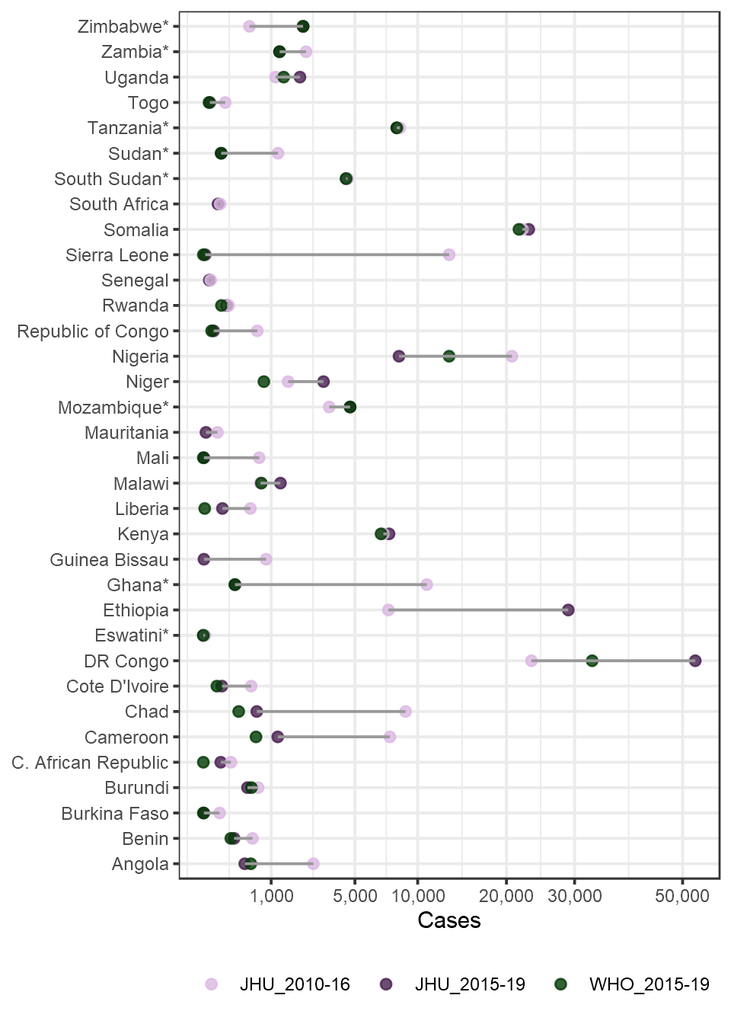

Figure 1: Mean annual cholera incident cases, 2010-2016 estimates versus preliminary 2015-2019 estimates. The difference between 2010-16 and 2015-19 estimates is shown with a grey line. Mean annual reports to WHO from 2015-2019 are displayed for reference. WHO reports were used for JHU_2015-19 estimates for countries marked with ’*’.

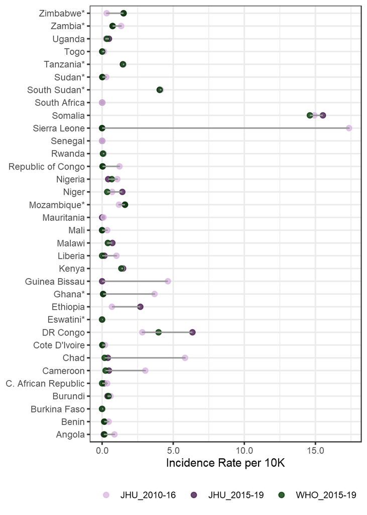

Figure 2: Mean annual cholera incidence rate, 2010-2016 estimates versus preliminary 2015-2019 estimates. The difference between 2010-16 and 2015-19 estimates is shown with a grey line. WHO reports were used for JHU_2015-19 estimates for countries marked with ’*’.

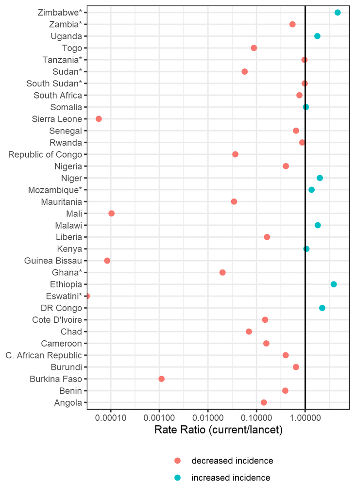

Figure 3: Rate ratio of preliminary 2015-2019 to 2010-2016 mean annual cholera incidence estimates

# Tables

Table 1: Mean annual incidence cases

| Country | Source | Years | Mean | 2.5% | 97.5% |
| --- | --- | --- | --- | --- | --- |
| Angola | JHU | 2015-2019 | 373 | 7 | 2043 |
| Angola | JHU | 2010-2016 | 2634 | 2605 | 2664 |
| Angola | WHO | 2015-2019 | 490 | 449 | 534 |
| Benin | JHU | 2015-2019 | 206 | 0 | 2036 |
| Benin | JHU | 2010-2016 | 526 | 515 | 535 |
| Benin | WHO | 2015-2019 | 164 | 138 | 193 |
| Burkina Faso | JHU | 2015-2019 | 0 | 0 | 0 |
| Burkina Faso | JHU | 2010-2016 | 58 | 53 | 63 |
| Burkina Faso | WHO | 2015-2019 | 0 | 0 | 0 |
| Burundi | JHU | 2015-2019 | 423 | 272 | 681 |
| Burundi | JHU | 2010-2016 | 653 | 634 | 671 |
| Burundi | WHO | 2015-2019 | 502 | 460 | 547 |
| C. African Republic | JHU | 2015-2019 | 66 | 0 | 480 |
| C. African Republic | JHU | 2010-2016 | 166 | 155 | 175 |
| C. African Republic | WHO | 2015-2019 | 0 | 0 | 0 |
| Cameroon | JHU | 2015-2019 | 1204 | 793 | 1960 |
| Cameroon | JHU | 2010-2016 | 7572 | 7526 | 7619 |
| Cameroon | WHO | 2015-2019 | 603 | 556 | 652 |
| Chad | JHU | 2015-2019 | 621 | 0 | 6810 |
| Chad | JHU | 2010-2016 | 8904 | 8834 | 8975 |
| Chad | WHO | 2015-2019 | 272 | 240 | 302 |
| Cote D’Ivoire | JHU | 2015-2019 | 75 | 0 | 728 |
| Cote D’Ivoire | JHU | 2010-2016 | 498 | 483 | 512 |
| Cote D’Ivoire | WHO | 2015-2019 | 40 | 28 | 52 |
| DR Congo | JHU | 2015-2019 | 52675 | 6554 | 273967 |
| DR Congo | JHU | 2010-2016 | 23438 | 23338 | 23537 |
| DR Congo | WHO | 2015-2019 | 32907 | 32551 | 33258 |
| Eswatini* | JHU | 2015-2019 | 0 | 0 | 0 |
| Eswatini* | JHU | 2010-2016 | 1 | 1 | 1 |
| Eswatini* | WHO | 2015-2019 | 0 | 0 | 0 |

[output cut: 72 more lines]

| Country | Source | Years | Mean | 2.5% | 97.5% |
| --- | --- | --- | --- | --- | --- |
| Angola | JHU | 2015-2019 | 0.0001227 | 0.0000025 | 0.0006725 |
| Angola | JHU | 2010-2016 | 0.0008673 | 0.0008575 | 0.0008770 |
| Angola | WHO | 2015-2019 | 0.0001614 | 0.0001478 | 0.0001758 |
| Benin | JHU | 2015-2019 | 0.0001811 | 0.0000000 | 0.0017938 |
| Benin | JHU | 2010-2016 | 0.0004631 | 0.0004539 | 0.0004718 |
| Benin | WHO | 2015-2019 | 0.0001449 | 0.0001216 | 0.0001701 |
| Burkina Faso | JHU | 2015-2019 | 0.0000000 | 0.0000000 | 0.0000001 |
| Burkina Faso | JHU | 2010-2016 | 0.0000295 | 0.0000271 | 0.0000321 |
| Burkina Faso | WHO | 2015-2019 | 0.0000000 | 0.0000000 | 0.0000000 |
| Burundi | JHU | 2015-2019 | 0.0003839 | 0.0002463 | 0.0006181 |
| Burundi | JHU | 2010-2016 | 0.0005919 | 0.0005754 | 0.0006087 |
| Burundi | WHO | 2015-2019 | 0.0004557 | 0.0004172 | 0.0004961 |
| C. African Republic | JHU | 2015-2019 | 0.0001416 | 0.0000000 | 0.0010306 |
| C. African Republic | JHU | 2010-2016 | 0.0003554 | 0.0003329 | 0.0003765 |
| C. African Republic | WHO | 2015-2019 | 0.0000000 | 0.0000000 | 0.0000000 |
| Cameroon | JHU | 2015-2019 | 0.0004831 | 0.0003183 | 0.0007864 |
| Cameroon | JHU | 2010-2016 | 0.0030381 | 0.0030196 | 0.0030571 |
| Cameroon | WHO | 2015-2019 | 0.0002420 | 0.0002231 | 0.0002616 |
| Chad | JHU | 2015-2019 | 0.0004067 | 0.0000000 | 0.0044604 |
| Chad | JHU | 2010-2016 | 0.0058318 | 0.0057855 | 0.0058785 |
| Chad | WHO | 2015-2019 | 0.0001780 | 0.0001572 | 0.0001978 |
| Cote D’Ivoire | JHU | 2015-2019 | 0.0000302 | 0.0000000 | 0.0002934 |
| Cote D’Ivoire | JHU | 2010-2016 | 0.0002008 | 0.0001947 | 0.0002064 |
| Cote D’Ivoire | WHO | 2015-2019 | 0.0000160 | 0.0000113 | 0.0000210 |
| DR Congo | JHU | 2015-2019 | 0.0063538 | 0.0007905 | 0.0330467 |
| DR Congo | JHU | 2010-2016 | 0.0028272 | 0.0028151 | 0.0028391 |
| DR Congo | WHO | 2015-2019 | 0.0039694 | 0.0039264 | 0.0040117 |
| Eswatini* | JHU | 2015-2019 | 0.0000000 | 0.0000000 | 0.0000000 |
| Eswatini* | JHU | 2010-2016 | 0.0000052 | 0.0000052 | 0.0000052 |
| Eswatini* | WHO | 2015-2019 | 0.0000000 | 0.0000000 | 0.0000000 |

[output cut: 72 more lines]

# Methods

## 2015-2019 JHU mean annual incidence estimates

We used suspected cholera surveillance reports at different administrative unit levels from the GTFCC cholera database to estimate the mean annual incidence of suspected cholera from 2015-2019 by 20 km x 20 km grid cells in a spatial Bayesian hierarchical modeling framework. The underlying cholera reports come from diverse sources ranging from weekly situational reports, NGO and outbreak reports, peer-reviewed literature, and the WHO. Multiple reports from different sources covering the same outbreak were considered to be independent observations of the same underlying process, thus contributing to measurement error in the reported case counts.

Countries were modeled separately, and model structures varied slightly between country to achieve better fits. Reported case counts were modeled with a Poisson distribution, and model terms include: a gridded covariate of distance to water, a spatial smoothing term similar to a conditional autoregressive (CAR) term ([Datta et al. (2019)](https://projecteuclid.org/journals/bayesian-analysis/volume-14/issue-4/Spatial-Disease-Mapping-Using-Directed-Acyclic-Graph-Auto-Regressive-DAGAR/10.1214/19-BA1177.full)), and a yearly random effect.

## 2010-2016 JHU mean annual incidence estimates

These estimates match the data reported in Lessler and Moore et al. (2018).

## WHO reference data

These country-level reports are taken from the WHO annual cholera reports published each year in the WER Bulletin. We calculated the mean annual incidence across 2015-2019 as a point of comparison for the new mean annual incidence estimates. Poisson-distributed variability was used to produce 95% CIs for WHO estimates.

For questions contact Elizabeth Lee at elizabeth.c.lee@jhu.edu